# Introduction to R

# The R language

R is an interpreted language, which means that most of its implementations execute instructions directly and freely, without previously compiling a program into machine-language instructions. Thus, users can typically access R through a command-line interpreter, such as conda’s command prompt (in Windows) or the terminal (in GNU/Linux). For instance, we can type `2+2`, press `Enter` (in a terminal) or `Ctrl`+`Enter` (in RStudio), the computer replies 4.

```r
2 + 2
```

```
## [1] 4
```

# Objects

In R, *objects* provide a means of accessing data stored in memory. Objects are referred to through *symbols* (variable names) or *variables*.

## Vectors

Vectors are the most basic objects in R. They can be thought of as contiguous cells containing data. Single numbers, such as `3.14`, and strings, such as `"pi"`, are still vectors (of length 1). Vectors of length 0 are also possible, and often useful.

R has six basic *atomic* vector types, where atomic means all their elements are of the same type. Those basic types are the following.

### Logical

Takes two possible values: `TRUE` (`T`) or `FALSE` (`F`).

```r
var_logical = TRUE
typeof(var_logical)
```

```
## [1] "logical"
```

```r
vector_logical = c(TRUE, FALSE, TRUE)
typeof(vector_logical)
```

```
## [1] "logical"
```

```r
vector_logical[1]
```

```
## [1] TRUE
```

```r
is.logical(vector_logical)
```

```
## [1] TRUE
```

```r
vector_logical[4]
```

```
## [1] NA
```

```r
is.logical(vector_logical[4])
```

```
## [1] TRUE
```

`NA`(not available) is a special type of data (by default logical).

### Integer

```r
var_int = 2L
typeof(var_int)
```

```
## [1] "integer"
```

```r
is.integer(var_int)
```

```
## [1] TRUE
```

```r
length(var_int)
```

```
## [1] 1
```

```r
var_int
```

```
## [1] 2
```

```r
var_int[1]
```

```
## [1] 2
```

```r
vector_int = c(var_int, 3L, 8L, 13:18)
typeof(vector_int)
```

```
## [1] "integer"
```

```r
vector_int
```

```
## [1]  2  3  8 13 14 15 16 17 18
```

```r
length(vector_int)
```

```
## [1] 9
```

```r
vector_int[10]
```

```
## [1] NA
```

```r
typeof(vector_int[10])
```

```
## [1] "integer"
```

### Double (numeric)

```r
var_double = 3.14
typeof(var_double)
```

```
## [1] "double"
```

```r
is.double(var_double)
```

```
## [1] TRUE
```

```r
is.numeric(var_double)
```

```
## [1] TRUE
```

```r
var_inf = var_double/0; var_inf
```

```
## [1] Inf
```

```r
var_nan = 0/0; var_nan
```

```
## [1] NaN
```

```r
typeof(c(var_inf, var_nan))
```

```
## [1] "double"
```

`Inf` and `NaN` are special types of double.

### Complex

```r
a = 5.2
b = 1.7
c = complex(real = a, imaginary = b); c
```

```
## [1] 5.2+1.7i
```

```r
typeof(c)
```

```
## [1] "complex"
```

```r
Re(c)
```

```
## [1] 5.2
```

```r
Im(c)
```

```
## [1] 1.7
```

```r
Mod(c)
```

```
## [1] 5.470832
```

```r
Arg(c)
```

```
## [1] 0.3159703
```

```r
Conj(c)
```

```
## [1] 5.2-1.7i
```

```r
sqrt(c)
```

```
## [1] 2.309852+0.367989i
```

### Character

```r
var_chr1 = "Hola"
var_chr2 = "Mundo"

typeof(var_chr1)
```

```
## [1] "character"
```

```r
c(var_chr1, var_chr2)
```

```
## [1] "Hola"  "Mundo"
```

```r
paste(var_chr1, var_chr2)
```

```
## [1] "Hola Mundo"
```

### Raw

```r
var_raw = as.raw(40); var_raw
```

```
## [1] 28
```

Notice the hexadecimal output.

```r
vect_raw = charToRaw("Hola Mundo"); vect_raw
```

```
##  [1] 48 6f 6c 61 20 4d 75 6e 64 6f
```

```r
rawToChar(vect_raw[1:4])
```

```
## [1] "Hola"
```

```r
typeof(vect_raw[1:4])
```

```
## [1] "raw"
```

## Lists

Lists are another kind of data storage. Lists have elements, but unlike vectors, those elements do not have to be of the same type. Here are some examples.

```r
my.contact = list(
  name = "Juan C",
  gitpage = "http://github.com/jlaria",
  age = 26,
  tags = c("#data-science", "#r", "#python")
)
my.contact
```

```
## $name
## [1] "Juan C"
##
## $gitpage
## [1] "http://github.com/jlaria"
##
## $age
## [1] 26
##
## $tags
## [1] "#data-science" "#r"            "#python"
```

We can access specific element of the list with `$`

```r
my.contact$tags
```

```
## [1] "#data-science" "#r"            "#python"
```

```r
typeof(my.contact$tags)
```

```
## [1] "character"
```

## Factors

Factors are special compound objects, used to describe cathegorical data.

```r
risk = factor(c("hi", "hi", "lo", "med", "lo", "hi")); risk
```

```
## [1] hi  hi  lo  med lo  hi
## Levels: hi lo med
```

```r
typeof(risk)
```

```
## [1] "integer"
```

```r
levels(risk)
```

```
## [1] "hi"  "lo"  "med"
```

```r
risk = factor(c("hi", "hi", "lo", "med", "lo", "hi"),
              levels=c("lo", "med", "hi"),
              ordered = T); risk
```

```
## [1] hi  hi  lo  med lo  hi
## Levels: lo < med < hi
```

## Matrices

A matrix is a collection of similar object arranged in rows and columns. Matrices are constructed column-wise so entries start in the upper left corner and run down the columns.

```r
X = matrix(1:8, nrow = 2, ncol = 4); X
```

```
##      [,1] [,2] [,3] [,4]
## [1,]    1    3    5    7
## [2,]    2    4    6    8
```

```r
dim(X)
```

```
## [1] 2 4
```

```r
t(X)
```

```
##      [,1] [,2]
## [1,]    1    2
## [2,]    3    4
## [3,]    5    6
## [4,]    7    8
```

```r
norm(X, "F")
```

```
## [1] 14.28286
```

```r
rownames(X) = c("obs 1", "obs 2")
colnames(X) = paste("var",1:4)
X
```

```
##       var 1 var 2 var 3 var 4
## obs 1     1     3     5     7
## obs 2     2     4     6     8
```

Matrices can also be created by column-binding or row-binding.

```r
x = 1:4
y = 5:8

cbind(x,y)
```

```
##      x y
## [1,] 1 5
## [2,] 2 6
## [3,] 3 7
## [4,] 4 8
```

```r
rbind(x,y)
```

```
##   [,1] [,2] [,3] [,4]
## x    1    2    3    4
## y    5    6    7    8
```

Multi-dimensional arrays are also posible.

```r
A = array(1:24, dim = c(2,4,3)); A
## , , 1
##
##      [,1] [,2] [,3] [,4]
## [1,]    1    3    5    7
## [2,]    2    4    6    8
##
## , , 2
##
##      [,1] [,2] [,3] [,4]
## [1,]    9   11   13   15
## [2,]   10   12   14   16
##
## , , 3
##
##      [,1] [,2] [,3] [,4]
## [1,]   17   19   21   23
## [2,]   18   20   22   24
```

# Indexing

R contains several constructs which allow access to individual elements or subsets through indexing operations.

There are three basic indexing operators: `[]`, `[[]]` and `$`.

```r
vector_int
```

```
## [1]  2  3  8 13 14 15 16 17 18
```

```r
vector_int[9]
```

```
## [1] 18
```

```r
vector_int[c(2,9)]
```

```
## [1]  3 18
```

```r
X[2,1]
```

```
## [1] 2
```

```r
X["obs 2", "var 1"]
```

```
## [1] 2
```

```r
A[1,2:3,1:2]
```

```
##      [,1] [,2]
## [1,]    3   11
## [2,]    5   13
```

Components of vectors can also be named.

```r
namedvector_int = c(1, 1, 2, 3, 5)
names(namedvector_int) = c("day 1", "day 2", "day 3", "day 4", "day 5")

namedvector_int["day 1"]
## day 1
##     1

namedvector_int[c("day 5", "day 2")]
## day 5 day 2
##     5     1
```

The operator `[[]]` is useful with list vectors. It can be used on atomics, tho.

```r
my.contact[4] # Returns a list with one element: a character vector
```

```
## $tags
## [1] "#data-science" "#r"            "#python"
```

```r
typeof(my.contact[4])
```

```
## [1] "list"
```

```r
my.contact[[1]] # Returns the character vector
```

```
## [1] "Juan C"
```

```r
typeof(my.contact[[1]])
```

```
## [1] "character"
```

The form `$` applies only to lists objects.

```r
my.contact$name
```

```
## [1] "Juan C"
```

```r
my.contact$"age"
```

```
## [1] 26
```

It is also possible to index vectors with `[]` using more complex constructions.

```r
a = c(1, 3, 4, -1, 2)
b = c(1, 2, 4, 8, 16)

a[b]
```

```
## [1]  1  3 -1 NA NA
```

```r
b[-4]
```

```
## [1]  1  2  4 16
```

```r
a[c(T,F,T)]
```

```
## [1]  1  4 -1
```

```r
b[risk]
```

```
## [1] 4 4 1 2 1 4
```

```r
b[]
```

```
## [1]  1  2  4  8 16
```

# Operators

R allows the use of arithmetic expressions using operators, which can be grouped using parentheses, mixed with function calls, and assigned to variables in a straightforward manner.

```r
x = 2; a = 1
y = 2 * (a + log(x)); y
```

```
## [1] 3.386294
```

Common vector/matrix opperators are listed here.

`-` Minus, can be unary or binary

```r
x = c(1,-1, 3)
y = c(2, 4, 6)

x-y
```

```
## [1] -1 -5 -3
```

`+` Plus, can be unary or binary

```r
x+y
```

```
## [1] 3 3 9
```

`!` Unary not

```r
b = c(T, F, T)

!b
```

```
## [1] FALSE  TRUE FALSE
```

`:` Sequence, binary (in model formulae: interaction)

```r
z = 3:8; z
```

```
## [1] 3 4 5 6 7 8
```

`*` Multiplication, binary

```r
x*y
```

```
## [1]  2 -4 18
```

```r
2*z
```

```
## [1]  6  8 10 12 14 16
```

```r
x*z
```

```
## [1]  3 -4 15  6 -7 24
```

`/` Division, binary

```r
x/y
```

```
## [1]  0.50 -0.25  0.50
```

`^` Exponentiation, binary

```r
x^y
```

```
## [1]   1   1 729
```

`%%` Modulus, binary

```r
7%%5
```

```
## [1] 2
```

`%/%` Integer divide, binary

```r
7%/%5
```

```
## [1] 1
```

`%*%` Matrix product, binary

```r
x %*% y
```

```
##      [,1]
## [1,]   16
```

`%o%` Outer product, binary

```r
M = x %o% y; M
```

```
##      [,1] [,2] [,3]
## [1,]    2    4    6
## [2,]   -2   -4   -6
## [3,]    6   12   18
```

`%x%` Kronecker product, binary

```r
x %x% M
```

```
##       [,1] [,2] [,3]
##  [1,]    2    4    6
##  [2,]   -2   -4   -6
##  [3,]    6   12   18
##  [4,]   -2   -4   -6
##  [5,]    2    4    6
##  [6,]   -6  -12  -18
##  [7,]    6   12   18
##  [8,]   -6  -12  -18
##  [9,]   18   36   54
```

`%in%` Matching operator, binary (in model formulae: nesting)

```r
x %in% z
```

```
## [1] FALSE FALSE  TRUE
```

`<` Less than, binary

```r
x < y
```

```
## [1] TRUE TRUE TRUE
```

`>` Greater than, binary

```r
y > x
```

```
## [1] TRUE TRUE TRUE
```

`==` Equal to, binary

```r
x == y
```

```
## [1] FALSE FALSE FALSE
```

`>=` Greater than or equal to, binary

`<=` Less than or equal to, binary

`&` And, binary, vectorized

```r
c(T, F, T) & c(F, F, T)
```

```
## [1] FALSE FALSE  TRUE
```

`&&` And, binary, not vectorized

```r
c(T, F, T) && c(F, F, T)
```

```
## [1] FALSE
```

`|` Or, binary, vectorized

```r
c(T, F, T) | c(F, F, T)
```

```
## [1]  TRUE FALSE  TRUE
```

`||` Or, binary, not vectorized

```r
c(T, F, T) || c(F, F, T)
```

```
## [1] TRUE
```

`<-` Left assignment, binary

```r
a <- 1; a
```

```
## [1] 1
```

`->` Right assignment, binary

```r
1 -> a; a
```

```
## [1] 1
```

# Control structures

Computation in R consists of sequentially evaluating **statements**. Statements, such as `a = 1` or `a^2`, can be separated by either `;` or a new line. They can also be grouped together using braces `{` and `}`, forming **blocks**.

## if

The `if/else` statement conditionally evaluates two statements. There is a `condition` which is evaluated and if the value is `TRUE` then the first statement is evaluated; otherwise the second statement will be evaluated.

```r
if(condition){
  statement 1
}else{
  statement 2
}
```

## Loops

R has three statements that provide explicit looping. They are `for`, `while` and `repeat`. The two built-in constructs, `next` and `break`, provide additional control over the evaluation. R provides other functions for implicit looping such as `tapply`, `apply`, and `lapply`. In addition many operations, especially arithmetic ones, are vectorized so you may not need to use a loop.

If there is some other way, avoid using loops in R, the former is probably faster.

### for

The syntax of the `for` loop is

```r
for(object in vector){
  statement
}
```

Notice that if `statement` is only one line, braces `{}` are not required.

### while

The syntax of the `while` loop is

```r
while(condition){
  statement
}
```

### repeat

The syntax of the `repeat` loop is

```r
repeat{
  statement
}
```

The `repeat` statement causes repeated evaluation of the body until a `break` is specifically requested. This means that you need to be careful when using `repeat` because of the danger of an infinite loop.

## Implicit loops

The `apply` family of fuctions avoids the explicit use of loop constructs. They manipulate slices of data from matrices, arrays, lists and dataframes in a repetitive way. Here are some important members of this family.

### apply

```r
X = matrix(rnorm(4*6), nrow = 4, ncol = 6); X
```

```
##            [,1]       [,2]         [,3]       [,4]       [,5]       [,6]
## [1,] -0.1398538 -0.8474962  0.263053931  0.1414031 -0.8963510  1.3495746
## [2,] -0.4295667 -0.1212743 -0.746109620  0.1038240  0.6493840  0.1495002
## [3,] -1.2940797 -0.4659704  2.228903162 -0.2086267 -0.3359033 -0.6135435
## [4,]  0.6960271 -1.5633602  0.003176074  1.4517935 -0.9893255 -0.6859187
```

```r
# We want to compute the mean of each column

col.means = apply(X, 2, mean); col.means
```

```
## [1] -0.29186829 -0.74952526  0.43725589  0.37209848 -0.39304895  0.04990314
```

```r
# col.means is a vector and it is equivalent to
col.means_for = rep(0, 6) # declare it
for(j in 1:6){
  col.means_for[j] = mean(X[,j])
}
col.means_for
```

```
## [1] -0.29186829 -0.74952526  0.43725589  0.37209848 -0.39304895  0.04990314
```

# Data manipulation

## Data frames

Data frames in R can be seen as lists of vectors, all with the same length. They are by far the most useful storage structure for data analysis in R. Data frames group vectors together into a 2D tables, where each vector is a column of the table. As happpens with lists in R, each column of a data frame can contain a different type of data, but since columns are vectors, every cell within a column must be of the same type.

There are many ways to create data frames in R, but we rarely have to type the data in R.

```r
df = data.frame(name = c("Juan", "Pedro", "María"),
                age = c(26, 33, 22),
                phone = c("666-849334", "666-837489", "666-029340") )
df
```

```
##    name age      phone
## 1  Juan  26 666-849334
## 2 Pedro  33 666-837489
## 3 María  22 666-029340
```

We can create a data frame from a previously defined 2D data matrix.

```r
X = matrix(1:8, nrow = 2, ncol = 4)

df = data.frame(X)
df
```

```
##   X1 X2 X3 X4
## 1  1  3  5  7
## 2  2  4  6  8
```

We can also assign names to columns and rows

```r
colnames(df) = paste0("Col", 1:4)
rownames(df) = paste0("Obs", 1:2)

df
```

```
##      Col1 Col2 Col3 Col4
## Obs1    1    3    5    7
## Obs2    2    4    6    8
```

We can delete and edit columns, rows, and cells.

```r
df = data.frame(matrix(rnorm(40), nrow=5, ncol=8))

df$X1 = NULL # delete column 1
df
```

```
##           X2          X3         X4         X5          X6         X7
## 1 -1.9346476  0.06458285 -0.4120862 -1.9468565 -0.08025261  1.4180478
## 2 -0.9958929  1.48321691  0.5136882 -2.0538819 -0.53234253  0.2668465
## 3  0.8462077 -2.65090547 -0.2462039  0.9069404 -0.70701776 -1.6458298
## 4  1.2895448 -0.54244654 -2.1345606  0.3553864  0.15219799 -1.0192780
## 5 -1.0235044 -0.10112281  0.3091994 -0.9810041  0.11460871 -1.4989134
##           X8
## 1 -0.0763690
## 2  1.3806002
## 3 -1.1720769
## 4  1.4595601
## 5  0.5267796
```

```r
df[,c(3,6)] = NULL # delete columns 3 and 6
df
```

```
##           X2          X3         X5          X6         X8
## 1 -1.9346476  0.06458285 -1.9468565 -0.08025261 -0.0763690
## 2 -0.9958929  1.48321691 -2.0538819 -0.53234253  1.3806002
## 3  0.8462077 -2.65090547  0.9069404 -0.70701776 -1.1720769
## 4  1.2895448 -0.54244654  0.3553864  0.15219799  1.4595601
## 5 -1.0235044 -0.10112281 -0.9810041  0.11460871  0.5267796
```

```r
df = df[-1, ] # remove row 1
df
```

```
##           X2         X3         X5         X6         X8
## 2 -0.9958929  1.4832169 -2.0538819 -0.5323425  1.3806002
## 3  0.8462077 -2.6509055  0.9069404 -0.7070178 -1.1720769
## 4  1.2895448 -0.5424465  0.3553864  0.1521980  1.4595601
## 5 -1.0235044 -0.1011228 -0.9810041  0.1146087  0.5267796
```

```r
df = df[,-c(4:6)] # remove columns 4,5,6
df
```

```
##           X2         X3         X5
## 2 -0.9958929  1.4832169 -2.0538819
## 3  0.8462077 -2.6509055  0.9069404
## 4  1.2895448 -0.5424465  0.3553864
## 5 -1.0235044 -0.1011228 -0.9810041
```

```r
df[2,] = -10 # edit row 2
df
```

```
##            X2          X3          X5
## 2  -0.9958929   1.4832169  -2.0538819
## 3 -10.0000000 -10.0000000 -10.0000000
## 4   1.2895448  -0.5424465   0.3553864
## 5  -1.0235044  -0.1011228  -0.9810041
```

```r
df$X5 = 5 # edit column X5
df
```

```
##            X2          X3 X5
## 2  -0.9958929   1.4832169  5
## 3 -10.0000000 -10.0000000  5
## 4   1.2895448  -0.5424465  5
## 5  -1.0235044  -0.1011228  5
```

Data frames with the same colums can be row-concatenated with `rbind`.

```r
df1 = data.frame(name = c("Pedro", "María"),
                age = c(33, 22),
                phone = c("666-837489", "666-029340") )
df2 = data.frame(name = c("Juan"),
                age = c(26),
                phone = c("666-849334") )

rbind(df1, df2)
```

```
##    name age      phone
## 1 Pedro  33 666-837489
## 2 María  22 666-029340
## 3  Juan  26 666-849334
```

Data frames with the same rows can be column-concatenated with `cbind`.

```r
df1 = data.frame(name = c("Juan", "Pedro", "María"),
                age = c(26, 33, 22))
df2 = data.frame( phone = c("666-849334", "666-837489", "666-029340") )

cbind(df1, df2)
```

```
##    name age      phone
## 1  Juan  26 666-849334
## 2 Pedro  33 666-837489
## 3 María  22 666-029340
```

## Data input

### The working directory

Every R session has a default location on the operating system’s file structure called the working directory.

The fuction `getwd()` tells what the current working directory is.

```r
getwd()
```

```
## [1] "/home/juank/Documents/Curso-Master/pythRon"
```

To change the working directory, use the `setwd` function. Be sure to enter the working directory as a character string (enclose it in quotes).

```r
setwd("~/juank/Downloads")
```

### Reading data

The `read.table` function reads a file in table format and automatically creates a data frame from it, with cases corresponding to rows and variables to columns in the file.

```r
df = read.table("data/protein.csv",
                header = T,
                sep = ",")
head(df)
```

```
##          Country RedMeat WhiteMeat Eggs Milk Fish Cereals Starch Nuts
## 1        Albania    10.1       1.4  0.5  8.9  0.2    42.3    0.6  5.5
## 2        Austria     8.9      14.0  4.3 19.9  2.1    28.0    3.6  1.3
## 3        Belgium    13.5       9.3  4.1 17.5  4.5    26.6    5.7  2.1
## 4       Bulgaria     7.8       6.0  1.6  8.3  1.2    56.7    1.1  3.7
## 5 Czechoslovakia     9.7      11.4  2.8 12.5  2.0    34.3    5.0  1.1
## 6        Denmark    10.6      10.8  3.7 25.0  9.9    21.9    4.8  0.7
##   Fr.Veg
## 1    1.7
## 2    4.3
## 3    4.0
## 4    4.2
## 5    4.0
## 6    2.4
```

The root path to read and write data is the current working directory, however we can specify the whole path to the data. Some reading functions allow to read from urls, not only local paths.

When reading files from the internet, it is often convenient to use the `nrows` parameter the first time, with a reasonable value, to check if we are getting the format right.

```r
df = read.table("http://hci.stanford.edu/courses/cs448b/data/ipasn/cs448b_ipasn.csv", nrows = 10)
df
```

```
##                      V1
## 1    date,l_ipn,r_asn,f
## 2    2006-07-01,0,701,1
## 3    2006-07-01,0,714,1
## 4   2006-07-01,0,1239,1
## 5   2006-07-01,0,1680,1
## 6   2006-07-01,0,2514,1
## 7   2006-07-01,0,3320,1
## 8  2006-07-01,0,3561,13
## 9   2006-07-01,0,4134,3
## 10  2006-07-01,0,5617,2
```

For instance, in this case, the data is a standard comma separated `.csv` file. We can set the parameter `sep=,` or just use the function `read.csv`.

```r
df = read.csv("http://hci.stanford.edu/courses/cs448b/data/ipasn/cs448b_ipasn.csv", nrows = 10)
df
```

```
##          date l_ipn r_asn  f
## 1  2006-07-01     0   701  1
## 2  2006-07-01     0   714  1
## 3  2006-07-01     0  1239  1
## 4  2006-07-01     0  1680  1
## 5  2006-07-01     0  2514  1
## 6  2006-07-01     0  3320  1
## 7  2006-07-01     0  3561 13
## 8  2006-07-01     0  4134  3
## 9  2006-07-01     0  5617  2
## 10 2006-07-01     0  6478  1
```

If you are working in a desktop computer and your file is in a local directory, you can use the function `file.choose` combined with `read.table` or `read.csv`.

```r
df = read.csv(file.choose())
```

### Writing data

To export data from R, we can use the `write.table` and `write.csv` functions. Notice that R will export the data to the current directory if we do not specify a root path.

# Functions

## Scope

Almost every programming language has a set of scoping rules, allowing the same name to be used for different objects. This allows, e.g., a local variable in a function to have the same name as a global object.

The **global environment** is the root of the user workspace. An assignment operation from the command line will cause the relevant object to belong to the global environment.

If we start up R and make an assignment, we are adding an entry in the global environment.

```r
a = 1234

ls()  # to list all the object in the (global) environment
```

```
##  [1] "a"               "A"               "b"
##  [4] "c"               "col.means"       "col.means_for"
##  [7] "df"              "df1"             "df2"
## [10] "j"               "M"               "my.contact"
## [13] "namedvector_int" "risk"            "var_chr1"
## [16] "var_chr2"        "var_double"      "var_inf"
## [19] "var_int"         "var_logical"     "var_nan"
## [22] "var_raw"         "vect_raw"        "vector_int"
## [25] "vector_logical"  "x"               "X"
## [28] "y"               "z"
```

Here we can see all the variables that we have defined earlier in this document, including `a`. We can think of environments as boxes that store objects, including other boxes.

We can define a new environment with the function `new.env`, and create variables inside that environment with `assign`.

```r
my.env = new.env()
assign("a", 123, envir = my.env)
ls(my.env)
```

```
## [1] "a"
```

```r
my.env$a
```

```
## [1] 123
```

The `$` form allows to create, read, and modify an object inside an environment.

```r
my.env$a = my.env$a*2
my.env$a
```

```
## [1] 246
```

Objects in R can be deleted with the function `rm`.

```r
rm(my.env) # deletes the environment my.env (including all the objects inside that enviroment)
```

We can not delete the global environment, but we can delete all the objects defined inside.

```r
rm(list = ls()) # deletes everything in the global environment

ls() # empty
## character(0)
```

Functions have their own environments.

## Function syntax

The syntax for writing a function is

```r
f = function(args){
  body
}
```

The first component of the function declaration is the keyword `function` which indicates to R that you want to create a function.

An argument list is a comma separated list of formal arguments. A formal argument can be a symbol, a statement of the form `symbol = expression`, or the special formal argument `...`

Generally functions are assigned to symbols but they don’t need to be. The value returned by the call to function is a function. If this is not given a name it is referred to as an `anonymous` function. Anonymous functions are most frequently used as arguments to other functions such as the `apply` family.

The return value of the function can be specified with `return`.

```r
add = function(x, y){
  return(x+y)
}
add(2,2)
```

```
## [1] 4
```

If the `return` value is not specified, by default the value of the last evaluation will be returned.

```r
add = function(x, y){
  x+y
}
add(2,2)
```

```
## [1] 4
```

For example, we can create a function that writes the date followed by the value of some variable.

```r
wlog = function(x){
  write(paste0(date(), "\t", x), "")
}

x = 3.14
wlog("Hola Mundo")
## Fri Aug 17 12:18:24 2018 Hola Mundo
wlog(x)
## Fri Aug 17 12:18:24 2018 3.14
```

Furthermore, we can specify default values.

```r
wlog = function(x, y=5){
  write(paste0(date(), "\t", x, "\t", y), "")
}

wlog(1.2)
## Fri Aug 17 12:18:24 2018 1.2 5
wlog(1.2, 2.4)
## Fri Aug 17 12:18:24 2018 1.2 2.4
```

We can specify with the default value `NULL` that a particular argument is optional.

```r
wlog = function(x, y=NULL){
  write(paste0(date(), "\t", x, "\t", y), "")
}

wlog(1.2)
## Fri Aug 17 12:18:24 2018 1.2
wlog(1.2, 2.4)
## Fri Aug 17 12:18:24 2018 1.2 2.4
```

The argument `...` can be passed to function calls inside our function, meaning an arbitrary number of arguments.

```r
wlog = function(..., printdate=T){
  write(paste0(
      {if(printdate)date() else NULL},
      ...), "")
}
wlog("\tHola mundo")
## Fri Aug 17 12:31:12 2018 Hola mundo
wlog(printdate = F, "Hola Mundo!")
## Hola Mundo!
wlog("\t x = ",2, "\t y = ", 5, "\t x + y = ", 2+5, "\t FIN.")
## Fri Aug 17 12:31:12 2018  x = 2   y = 5   x + y = 7   FIN.
```

# Visualization with `ggplot2`

`ggplot2` is a flexible and powerful R package for producing graphics, with a deep underlying grammar based on the **g**rammar and **g**raphics concept.

## Installation

To use `ggplot2`, we must first install it. There are several ways to do it.

**Option A**

[figure not shown]

Open Anaconda prompt and type,

```bash
conda install -c conda-forge r-ggplot2
```

**Option B** Open R and run the following code

```r
install.packages("ggplot2")
```

## Data

To access fuctions and data in an R package, `ggplot2` in this case, we can load it with the `library` function. We are also installing `ISLR` R package, which includes the dataset that we are going to use in the examples.

```r
if(!require("ISLR"))install.packages("ISLR")
```

```r
library(ggplot2)
library(ISLR)
```

In particular, we will load the `Auto` dataset. It includes information about gas mileage, horsepower, acceleration and other indicators of popular car models between 1970 and 1982. We first examine the data with the fuction `head`.

```r
data("Auto")
head(Auto)
```

| mpg | cylinders | displacement | horsepower | weight | acceleration | year | origin | name |
| --- | --- | --- | --- | --- | --- | --- | --- | --- |
| 18 | 8 | 307 | 130 | 3504 | 12.0 | 70 | 1 | chevrolet chevelle malibu |
| 15 | 8 | 350 | 165 | 3693 | 11.5 | 70 | 1 | buick skylark 320 |
| 18 | 8 | 318 | 150 | 3436 | 11.0 | 70 | 1 | plymouth satellite |
| 16 | 8 | 304 | 150 | 3433 | 12.0 | 70 | 1 | amc rebel sst |
| 17 | 8 | 302 | 140 | 3449 | 10.5 | 70 | 1 | ford torino |
| 15 | 8 | 429 | 198 | 4341 | 10.0 | 70 | 1 | ford galaxie 500 |

## Components of a `ggplot2`

There are three key components in every `ggplot2`

1. **Data**
2. **Aesthetic mapping** – Relates variables in the data with visual properties.
3. **Layers** – Describe how to render each observation. There has to be at leat one layer.

For example,

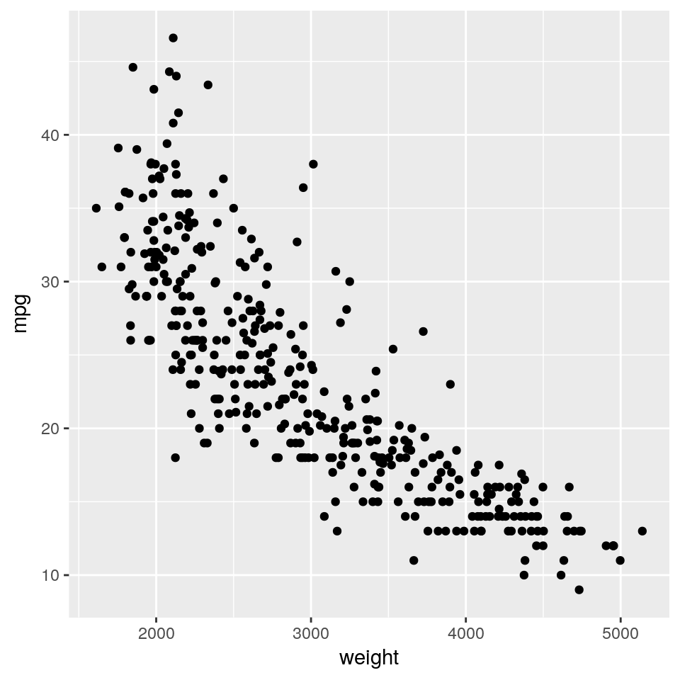

```r
ggplot(data = Auto,
       mapping = aes(x = weight, y = mpg))+ # Notice the +
geom_point()
```

This scatterplot is defined by the following components.

1. Data: `Auto`
2. Aesthetic mapping: Vehicle weight is mapped to `x`, and fuel economy to `y` position
3. Layer: `geom_point()` – scatterplot

The structure of this function call is the following.

- Data and aesthetic mappings are supplied in the function `ggplot2`
- Layers are added on with `+`

## Aesthetics

To add extra variables to a plot, we can use other aesthetics such as color, shape, and size. They work in the same way as the `x` and `y` aesthetics, and are added into the call to `aes()`.

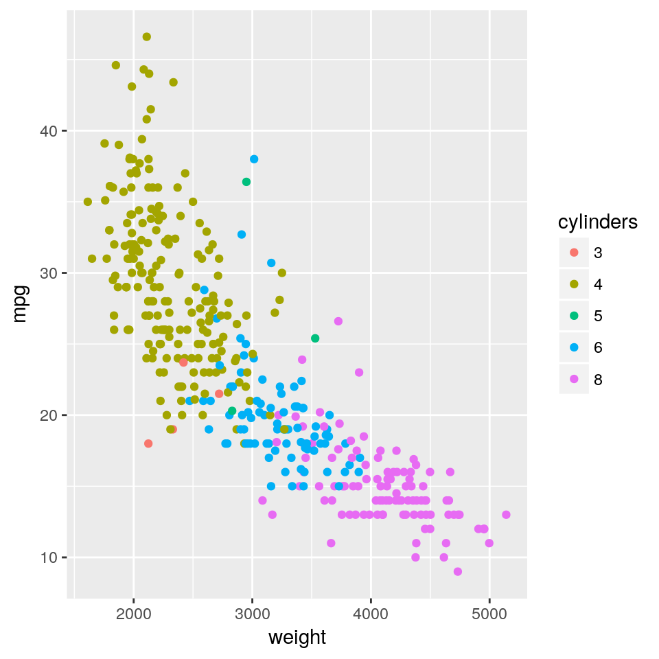

```r
Auto$cylinders = factor(Auto$cylinders)

ggplot(data = Auto,
       mapping = aes(x = weight, y = mpg, color = cylinders))+
geom_point()
```

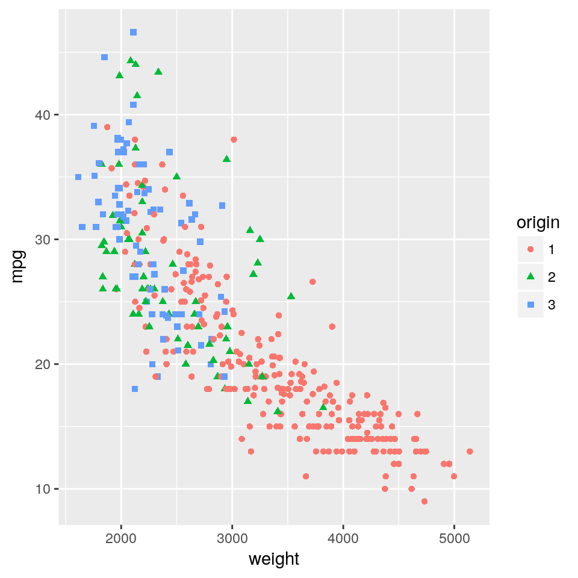

```r
Auto$origin = factor(Auto$origin)
ggplot(data = Auto,
       mapping = aes(x = weight, y = mpg, color = origin, shape = origin))+
geom_point()
```

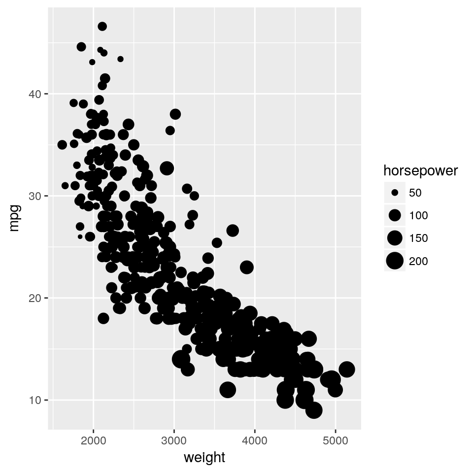

```r
ggplot(data = Auto,
       mapping = aes(x = weight, y = mpg, size = horsepower))+
geom_point()
```

## Plot Geoms

### Smoother

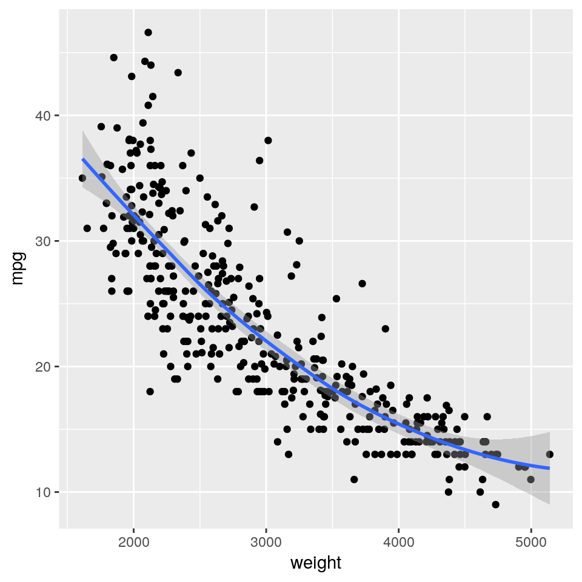

```r
ggplot(data = Auto,
       mapping = aes(x = weight, y = mpg))+
  geom_point()+
  geom_smooth()
## `geom_smooth()` using method = 'loess'
```

### Boxplots

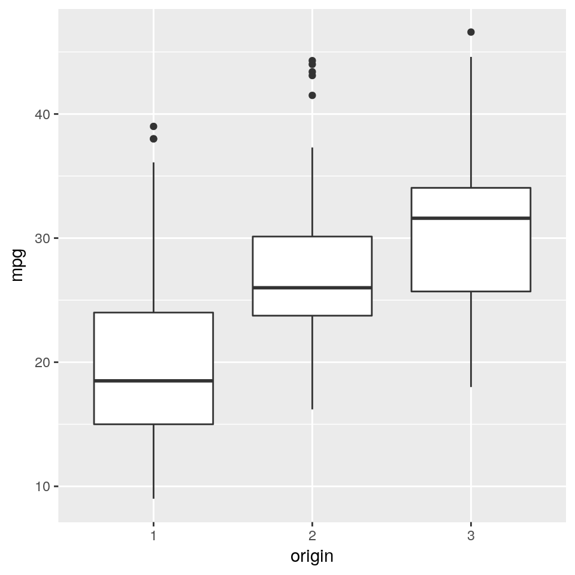

```r
ggplot(data = Auto,
       mapping = aes(x = origin, y = mpg))+
  geom_boxplot()
```

### Histograms

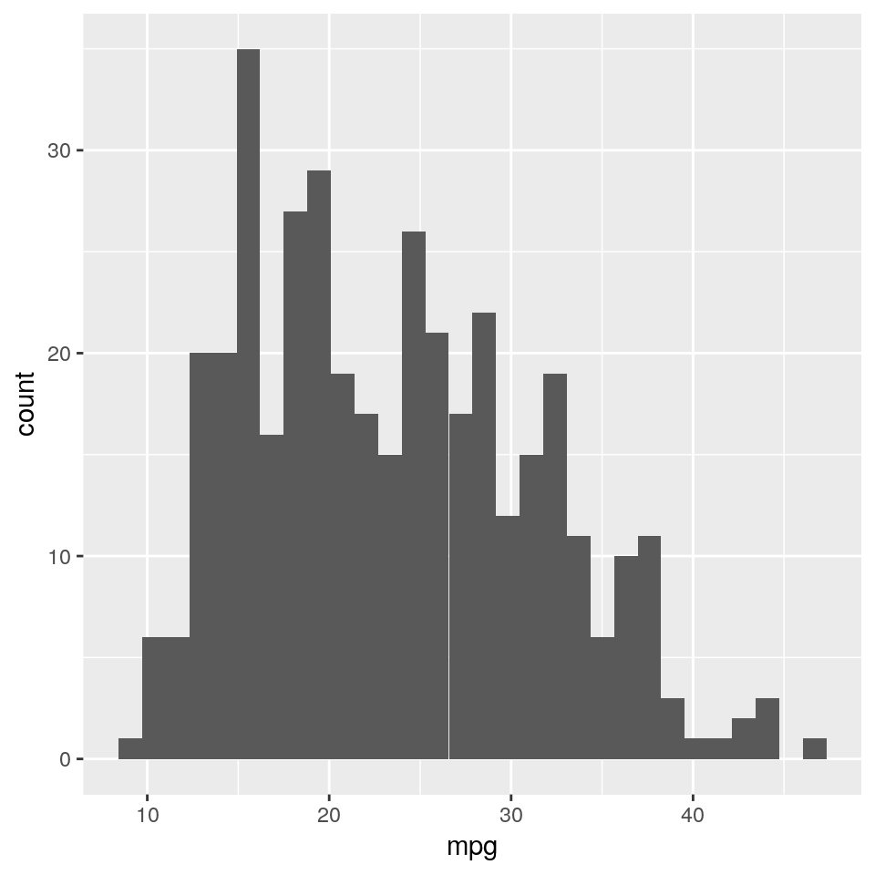

```r
ggplot(data = Auto,
       mapping = aes(x = mpg))+
  geom_histogram()
## `stat_bin()` using `bins = 30`. Pick better value with `binwidth`.
```

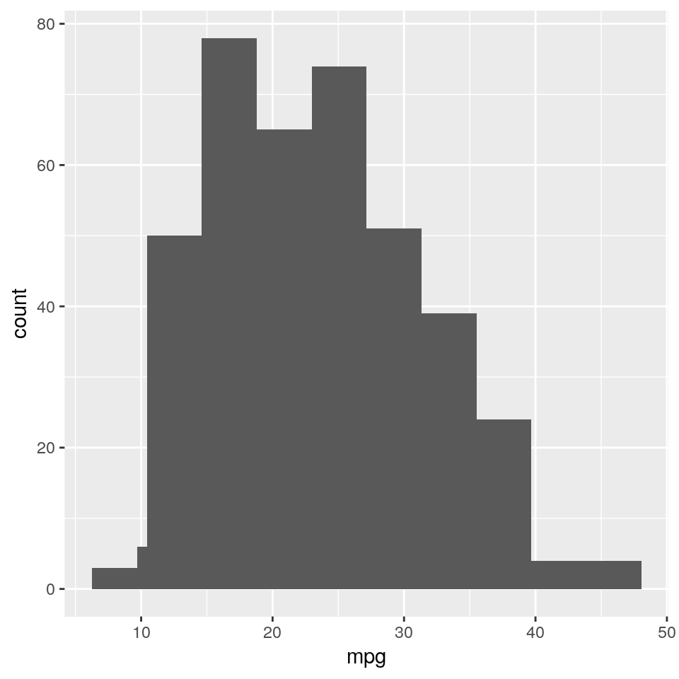

```r
ggplot(data = Auto,
       mapping = aes(x = mpg))+
  geom_histogram()+
  stat_bin(bins = 10)
## `stat_bin()` using `bins = 30`. Pick better value with `binwidth`.
```

# Going parallel

In this section, we are going to study how to execute parallel code in R.

Let’s start with a simple example. The following code evaluates candidates for the Mandelbrot set.

[figure not shown]

```r
x = seq(-2, 1, length.out = 500)
y = seq(-1.5, 1.5, length.out = 500)

grid = expand.grid( x=x, y=y)
c = complex(real = grid$x,
            imaginary = grid$y)

N = 50
divergence = rep(0, length(c))
z = divergence
index = rep(T,  length(c))
for(n in 1:N){
  z[index] = z[index]^2 + c[index]
  index = Mod(z) < 2
  divergence[index] = n
}

Z = matrix(divergence, nrow = 500, ncol = 500)
image( x, y, Z, col =gray((0:N)/N))
```

## The `foreach` loop

The `foreach` loop is the analogous of the `for` loop, when working in parallel. It is distributed in the `foreach` package.

```r
library(foreach)
```

For example, the following `for` and `foreach` loops are equivalent.

```r
# For loop
s = rep(0, 10)
for (i in 1:10) {
  s[i] = sqrt(i)
}
s
```

```
##  [1] 1.000000 1.414214 1.732051 2.000000 2.236068 2.449490 2.645751
##  [8] 2.828427 3.000000 3.162278
```

```r
# Foreach loop
s = foreach(i = 1:10, .combine = 'c')%do%{
  sqrt(i)
}
s
```

```
##  [1] 1.000000 1.414214 1.732051 2.000000 2.236068 2.449490 2.645751
##  [8] 2.828427 3.000000 3.162278
```

Notice the syntax of the `foreach` function. Its first argument is the iterator variable, and it returns a vector (because we used the `.combine = 'c'` parameter; by default it returns a list). The operator `%do%` is telling the `foreach` function to run sequentially. Alternatively, we can use `%dopar%` to run in parallel, if we specified a parallel backend previously.

We can adapt the Mandelbrot script to use a `foreach` outer loop.

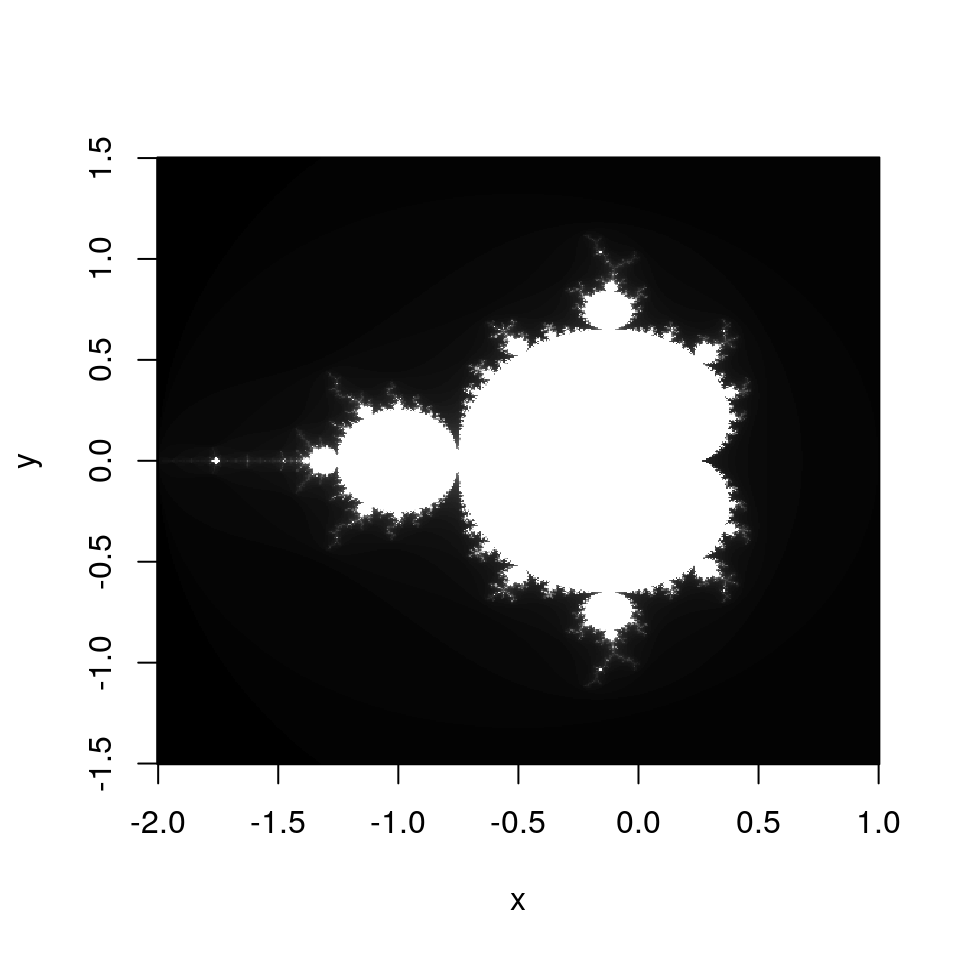

```r
library(tictoc)
library(foreach)

tic()
x = seq(-2, 1, length.out = 500)
y = seq(-1.5, 1.5, length.out = 500)

grid = expand.grid( x=x, y=y)
c_set = split(complex(real = grid$x,
            imaginary = grid$y), rep(1:4, each = 500*500/4))


N = 100
divergence.ag = foreach( i=1:4, .combine = "c")%do%{
  c = c_set[[i]]
  divergence = rep(0, length(c))
  z = divergence
  index = rep(T,  length(c))
  for(n in 1:N){
    z[index] = z[index]^2 + c[index]
    index = Mod(z) < 2
    divergence[index] = n
  }
  divergence
}

toc()
## 1.087 sec elapsed

Z = matrix(divergence.ag, nrow = 500, ncol = 500)
image( x, y, Z, col =gray((0:N)/N))
```

## Backends

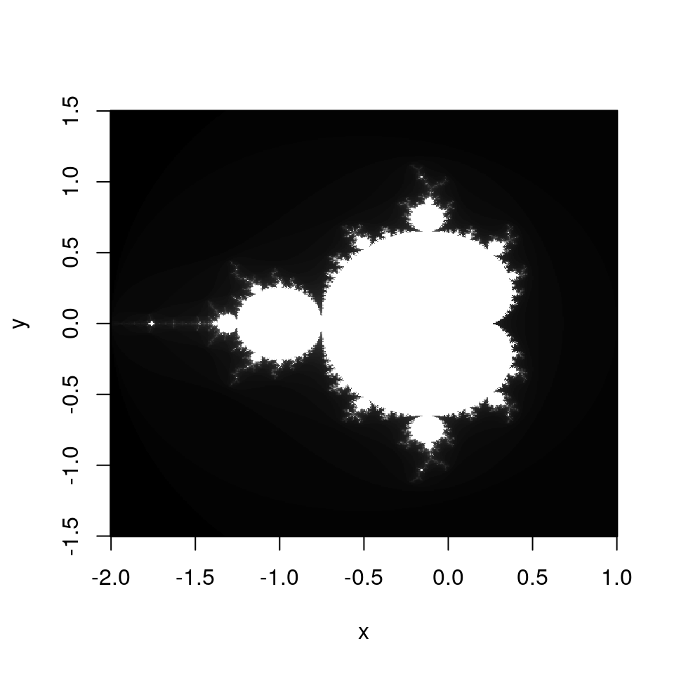

```r
library(foreach)
library(doParallel)

cl = makeCluster(3)
registerDoParallel(cl)

tic()

x = seq(-2, 1, length.out = 500)
y = seq(-1.5, 1.5, length.out = 500)

grid = expand.grid( x=x, y=y)
c_set = split(complex(real = grid$x,
            imaginary = grid$y), rep(1:4, each = 500*500/4))


N = 100
divergence.ag = foreach( i=1:4, .combine = "c")%dopar%{
  c = c_set[[i]]
  divergence = rep(0, length(c))
  z = divergence
  index = rep(T,  length(c))
  for(n in 1:N){
    z[index] = z[index]^2 + c[index]
    index = Mod(z) < 2
    divergence[index] = n
  }
  divergence
}
toc()
## 0.709 sec elapsed

Z = matrix(divergence.ag, nrow = 500, ncol = 500)
image( x, y, Z, col =gray((0:N)/N))
```